# Longitudinal Data FACES, KUSS, PPMD

A.I. Georgevici

9 4 2020

## Import the data

### Following assumptions:

- the rows are in chronological order, rows with no entry still have the time axis
- in the variables: “p1, p2, p3 … interv” no entry represents a “0” and “N” represents N/A (not available)

### A quick birds-eye view of the column structure

```
## # A tibble: 4,484 x 26
##    pseudo_id real_id  time    p1    p2    p3    p4    p5    p6    p7    p8    p9
##    <chr>     <chr>   <int> <int> <int> <int> <int> <int> <int> <int> <int> <int>
##  1 14181586  141815~     1     0     0     0     0     0     0     0     0     0
##  2 14181586  141815~     2     1     1     1     1     1     1     1     0     0
##  3 14181586  141815~     3     1     1     1     1     1     1     1     0     0
##  4 14181586  141815~     4     1     1     1     1     1     1     1     0     0
##  5 14181586  141815~     5     1     1     1     1     1     1     1     0     0
##  6 14181586  141815~     6     1     1     1     0     1     1     1     0     0
##  7 14181586  141815~     7     1     1     1     1     1     1     1     0     0
##  8 14181586  141815~     8     1     0     0     0     0     1     0     0     1
##  9 14181586  141815~     9     0     0     0     0     0     1     0     0     0
## 10 14181586  141815~    10     0     0     1     0     0     1     1     0     0
## # ... with 4,474 more rows, and 14 more variables: p10 <int>, p11 <int>,
## #   p12 <int>, p13 <int>, p14 <int>, p15 <int>, faces <int>, kuss <int>,
## #   w <int>, g <int>, r <int>, b <int>, m <int>, interv <int>
```

### The percent of missing values per column. By study design, a patient has either FACES or KUSS values (never both)

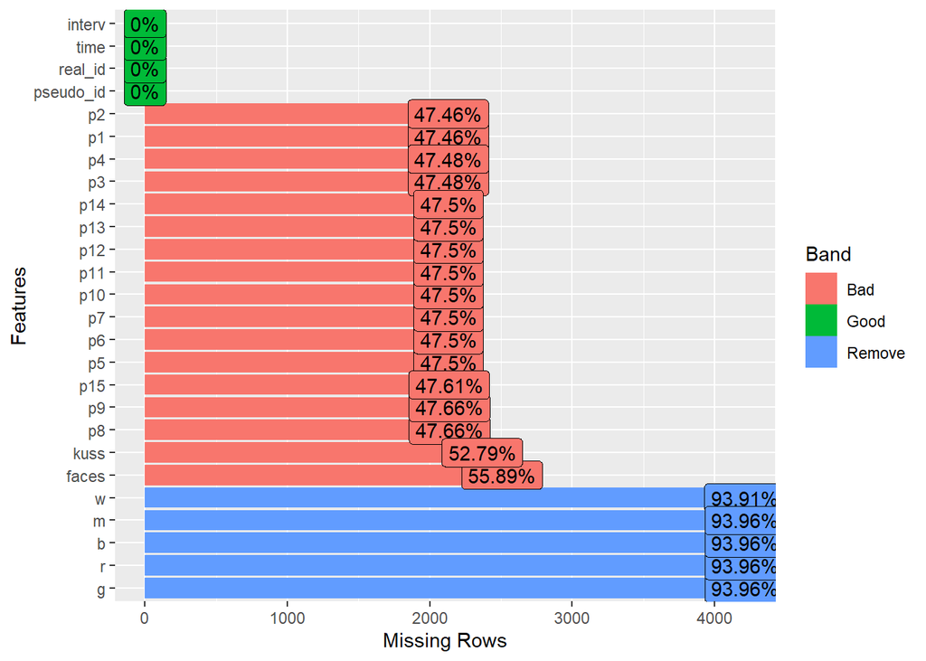

### A summary of the percentiles of numeric columns

| variable | missing_rate | mean | sd | hist |
| --- | --- | --- | --- | --- |
| time | 0.00000 | 7.24620874 | 4.5700776 | ▇▅▁▁▁ |
| p1 | 47.45763 | 0.15237691 | 0.3594621 | ▇▁▁▁▂ |
| p2 | 47.45763 | 0.13200340 | 0.3398182 | ▇▁▁▁▁ |
| p3 | 47.47993 | 0.20849257 | 0.4063170 | ▇▁▁▁▂ |
| p4 | 47.47993 | 0.17749469 | 0.3821680 | ▇▁▁▁▂ |
| p5 | 47.50223 | 0.09515718 | 0.2934943 | ▇▁▁▁▁ |
| p6 | 47.50223 | 0.28334749 | 0.4646479 | ▇▁▁▁▁ |
| p7 | 47.50223 | 0.30033985 | 0.4585031 | ▇▁▁▁▃ |
| p8 | 47.65834 | 0.13932680 | 0.3463610 | ▇▁▁▁▁ |
| p9 | 47.65834 | 0.30762676 | 0.4616095 | ▇▁▁▁▃ |
| p10 | 47.50223 | 0.09133390 | 0.2881446 | ▇▁▁▁▁ |
| p11 | 47.50223 | 0.05437553 | 0.2268054 | ▇▁▁▁▁ |
| p12 | 47.50223 | 0.10875106 | 0.3113928 | ▇▁▁▁▁ |
| p13 | 47.50223 | 0.08326253 | 0.2763373 | ▇▁▁▁▁ |
| p14 | 47.50223 | 0.23024639 | 0.4210799 | ▇▁▁▁▂ |
| p15 | 47.61374 | 0.05363985 | 0.2253536 | ▇▁▁▁▁ |
| faces | 55.88760 | 1.30637007 | 1.9524364 | ▇▁▁▁▁ |
| kuss | 52.78769 | 0.47189419 | 1.2940860 | ▇▁▁▁▁ |
| w | 93.91169 | 0.08058608 | 0.3221430 | ▇▁▁▁▁ |
| g | 93.95629 | 0.13653137 | 0.3648863 | ▇▁▁▁▁ |
| r | 93.95629 | 0.07749077 | 0.2942202 | ▇▁▁▁▁ |
| b | 93.95629 | 0.04797048 | 0.2747146 | ▇▁▁▁▁ |
| m | 93.95629 | 0.12546125 | 0.3637985 | ▇▁▁▁▁ |
| interv | 0.00000 | 0.05374665 | 0.2255422 | ▇▁▁▁▁ |

### The structure of KUSS

- kuss takes the max value from “kuss” or “sum of w, g, r, b, m”
- replace the “w,g,r,b,m” with NA if kuss is NA

In the missing_rate the percent of missing “w, g, r, b, m” when FACES is available !

| variable | missing_rate | mean | sd | hist |
| --- | --- | --- | --- | --- |
| w | 87.17105 | 0.08058608 | 0.3221430 | ▇▁▁▁▁ |
| g | 87.26504 | 0.13653137 | 0.3648863 | ▇▁▁▁▁ |
| r | 87.26504 | 0.07749077 | 0.2942202 | ▇▁▁▁▁ |
| b | 87.26504 | 0.04797048 | 0.2747146 | ▇▁▁▁▁ |
| m | 87.26504 | 0.12546125 | 0.3637985 | ▇▁▁▁▁ |

The distribution of KUSS in percents of observations per sum of KUSS

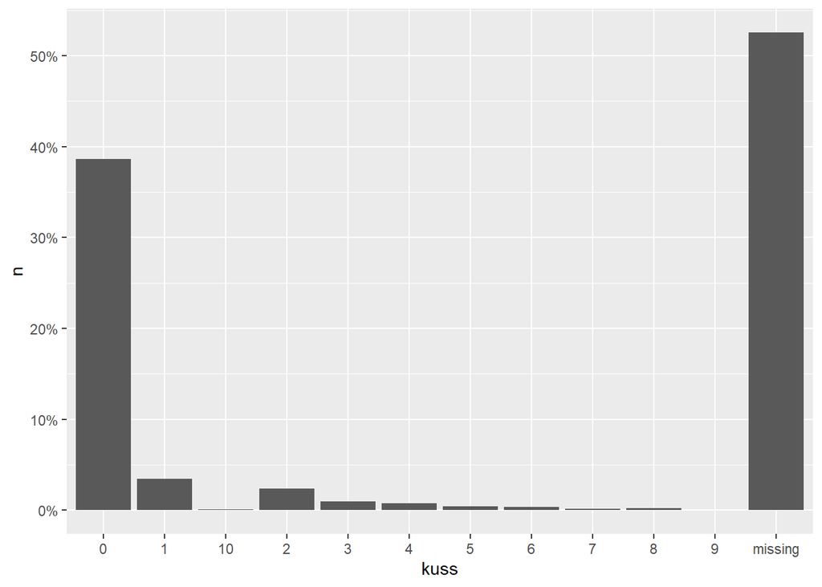

The values in the original PPMD, there’s a value “2” and “6”. Those values are corrected to 1.

```
## # A tibble: 5 x 2
##   value     n
##   <int> <int>
## 1     0    15
## 2     1    15
## 3     2     1
## 4     6     1
## 5    NA    15
```

There are also missing values mixed with present values. Imputing 0 in those columns At time1 (Aufwachraum) the PPMD is NA, imputing NA in those rows.

| pseudo_id | real_id | time | p1 | p2 | p3 | p4 | p5 | p6 | p7 | p8 | p9 | p10 | p11 | p12 | p13 | p14 | p15 | faces | kuss | w | g | r | b | m | interv | nrNA |
| --- | --- | --- | --- | --- | --- | --- | --- | --- | --- | --- | --- | --- | --- | --- | --- | --- | --- | --- | --- | --- | --- | --- | --- | --- | --- | --- |
| 270260 | 15291270 | 2 | 0 | 0 | 0 | 1 | 0 | 1 | 1 | NA | NA | 0 | 0 | 0 | 0 | 1 | NA | 2 | NA | NA | NA | NA | NA | NA | 0 | 3 |
| 270260 | 15291270 | 3 | 0 | 0 | 0 | 1 | 0 | 1 | 1 | 0 | 0 | 0 | 0 | 0 | 0 | 1 | NA | 0 | NA | NA | NA | NA | NA | NA | 0 | 1 |
| 895200 | 15314895 | 2 | 0 | 0 | 1 | 1 | 1 | 1 | 1 | NA | 0 | 0 | 0 | 0 | 1 | 1 | NA | NA | 2 | NA | NA | NA | NA | NA | 0 | 2 |
| 825140 | 15322825 | 9 | 0 | 1 | 1 | 0 | NA | NA | NA | NA | NA | NA | NA | NA | NA | NA | NA | 2 | NA | NA | NA | NA | NA | NA | 0 | 11 |
| 103310 | 15337103 | 6 | 0 | 0 | 0 | NA | NA | NA | NA | NA | NA | NA | NA | NA | NA | NA | NA | NA | NA | NA | NA | NA | NA | NA | 0 | 12 |
| 15451684 | 15451684 | 2 | 0 | 0 | NA | 0 | 0 | 0 | 1 | 0 | NA | 0 | 0 | 0 | 0 | 0 | NA | 0 | NA | NA | NA | NA | NA | NA | 0 | 3 |
| 16498225 | 16498225 | 2 | 0 | 0 | 1 | 1 | 1 | 0 | 1 | NA | NA | 0 | 0 | 0 | 0 | 1 | 0 | NA | 0 | 0 | 0 | 0 | 0 | 0 | 0 | 2 |
| 16537681 | 16537681 | 2 | 0 | 0 | 0 | 1 | 1 | 1 | 1 | NA | NA | 0 | 0 | 0 | 0 | 0 | 0 | 2 | NA | NA | NA | NA | NA | NA | 0 | 2 |
| 16537681 | 16537681 | 3 | 0 | 0 | 0 | 1 | 0 | 1 | 1 | NA | NA | 0 | 0 | 0 | 0 | 0 | 0 | 0 | NA | NA | NA | NA | NA | NA | 0 | 2 |
| 16539486 | 16539486 | 2 | 0 | 0 | 0 | 0 | 0 | 1 | 1 | NA | NA | 0 | 0 | 0 | 0 | 1 | 0 | 2 | NA | NA | NA | NA | NA | NA | 0 | 2 |
| 16591661 | 16591661 | 13 | 0 | 0 | 0 | 0 | 0 | 0 | 0 | 0 | 0 | 0 | 0 | 0 | 0 | 0 | NA | NA | 0 | NA | NA | NA | NA | NA | 0 | 1 |
| 822 | 18036822 | 2 | 1 | 1 | 1 | 1 | 0 | 0 | 1 | NA | NA | 0 | 0 | 1 | 0 | 0 | 0 | NA | 2 | NA | NA | NA | NA | NA | 0 | 2 |

The distribution of PPMD in percents of observations per sum of ppmd

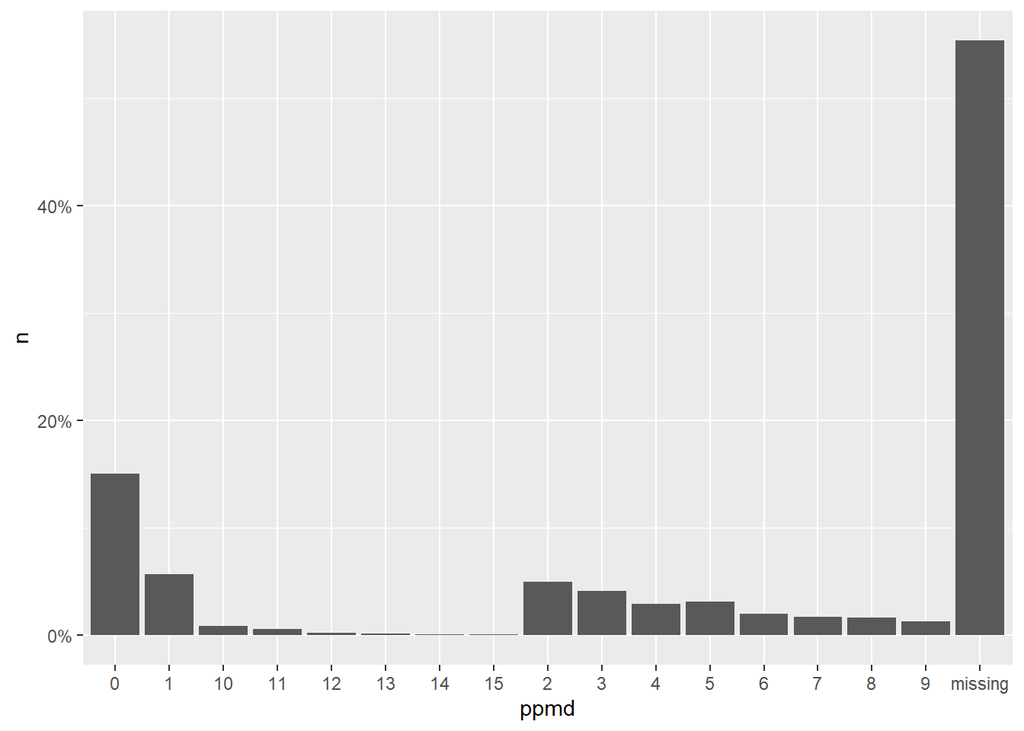

The number of observations per patient (pseudo_id)

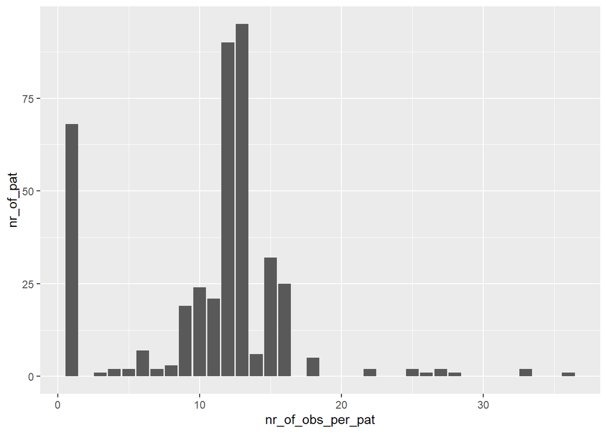

The number of interventions and non-interventions

| interv | n |
| --- | --- |
| 0 | 4243 |
| 1 | 241 |

The number of observations (clustered per intervention) with the sum of FACES

```
## [[1]]
## # A tibble: 20 x 7
##    pseudo_id  time  kuss faces  ppmd sum_scales interv
##    <chr>     <int> <dbl> <int> <dbl>      <dbl>  <int>
##  1 14181586      1     0    NA    NA          0      0
##  2 14181586     14     0    NA    NA          0      0
##  3 14181586     15     0    NA    NA          0      0
##  4 769140        7     0    NA     0          0      0
##  5 605200        6    NA     0    NA          0      0
##  6 605200       10    NA    NA    NA          0      0
##  7 605200       12    NA    NA    NA          0      0
##  8 605200       13    NA    NA    NA          0      0
##  9 605200       14    NA    NA    NA          0      0
## 10 605200       15    NA    NA    NA          0      0
## 11 605200       19    NA     0    NA          0      0
```

[output cut: 29 more lines]

A dataset with a positive sum_scales (> 0)

```
## # A tibble: 2,144 x 28
##    pseudo_id real_id  time    p1    p2    p3    p4    p5    p6    p7    p8    p9
##    <chr>     <chr>   <int> <int> <dbl> <dbl> <dbl> <dbl> <dbl> <dbl> <dbl> <dbl>
##  1 14181586  141815~     2     1     1     1     1     1     1     1     0     0
##  2 14181586  141815~     3     1     1     1     1     1     1     1     0     0
##  3 14181586  141815~     4     1     1     1     1     1     1     1     0     0
##  4 14181586  141815~     5     1     1     1     1     1     1     1     0     0
##  5 14181586  141815~     6     1     1     1     0     1     1     1     0     0
##  6 14181586  141815~     7     1     1     1     1     1     1     1     0     0
##  7 14181586  141815~     8     1     0     0     0     0     1     0     0     1
##  8 14181586  141815~     9     0     0     0     0     0     1     0     0     0
##  9 14181586  141815~    10     0     0     1     0     0     1     1     0     0
## 10 14181586  141815~    11     0     0     1     0     0     1     1     0     0
## # ... with 2,134 more rows, and 16 more variables: p10 <dbl>, p11 <dbl>,
## #   p12 <dbl>, p13 <dbl>, p14 <dbl>, p15 <dbl>, faces <int>, kuss <dbl>,
## #   w <int>, g <int>, r <int>, b <int>, m <int>, interv <int>, ppmd <dbl>,
## #   sum_scales <dbl>
```

Kuss Scale: n = nr. of children, interv (0/1) no intervention / intervention

```
## $`0`
## # A tibble: 9 x 3
## # Groups:   interv [1]
##   interv  kuss     n
##    <int> <dbl> <int>
## 1      0     0   522
## 2      0     1   152
## 3      0     2   103
## 4      0     3    37
## 5      0     4     9
## 6      0     5     2
## 7      0     6     1
## 8      0     8     2
## 9      0    NA  1090
##
## $`1`
## # A tibble: 12 x 3
## # Groups:   interv [1]
##    interv  kuss     n
##     <int> <dbl> <int>
##  1      1     0     5
##  2      1     1     2
##  3      1     2     5
##  4      1     3     6
##  5      1     4    25
##  6      1     5    16
##  7      1     6    14
##  8      1     7     7
##  9      1     8     9
## 10      1     9     2
## 11      1    10     3
## 12      1    NA   132
```

Faces Scale: n = nr. of children, interv (0/1) no intervention / intervention

```
## $`0`
## # A tibble: 10 x 3
## # Groups:   interv [1]
##    interv faces     n
##     <int> <int> <int>
##  1      0     0   250
##  2      0     1    83
##  3      0     2   601
##  4      0     3    12
##  5      0     4    42
##  6      0     5     1
##  7      0     6    24
##  8      0     8    14
##  9      0    10     6
## 10      0    NA   885
##
## $`1`
## # A tibble: 9 x 3
## # Groups:   interv [1]
##   interv faces     n
##    <int> <int> <int>
## 1      1     0     1
## 2      1     2    12
## 3      1     3     3
## 4      1     4    34
## 5      1     5     1
## 6      1     6    37
## 7      1     8    31
## 8      1    10    13
## 9      1    NA    94
```

PPMD Scale: n = nr. of children, interv (0/1) no intervention / intervention

```
## $`0`
## # A tibble: 17 x 3
## # Groups:   interv [1]
##    interv  ppmd     n
##     <int> <dbl> <int>
##  1      0     0   113
##  2      0     1   253
##  3      0     2   224
##  4      0     3   185
##  5      0     4   127
##  6      0     5   137
##  7      0     6    87
##  8      0     7    68
##  9      0     8    61
## 10      0     9    44
```

[output cut: 26 more lines]

162 children that had intervention from a total of 413.

Below the number of interventions per children

| nr_of_interv_per_children | nr_of_children |
| --- | --- |
| 1 | 113 |
| 2 | 31 |
| 3 | 10 |
| 4 | 5 |
| 5 | 2 |
| 6 | 1 |